# TD3 Analyse de la variance et Analyse de la covariance

Antoine Bichat - Émilie Lebarbier

# Préliminaires

## Librairies

```r
library(ppcor)
library(car)
library(lsmeans)
library(tidyverse)
theme_set(theme_bw())
```

## Chargement des données

```r
myData <- read.table(file = "bats.csv", sep = ";", skip= 3, header = TRUE)
str(myData)
```

```
## 'data.frame':    63 obs. of  8 variables:
##  $ Species: Factor w/ 63 levels " Anoura  geofroyi ",..: 52 20 19 12 16 17 47 29 55 41 ...
##  $ Diet   : int  1 1 1 1 1 1 1 1 1 1 ...
##  $ Clade  : Factor w/ 4 levels "I","II","III",..: 1 1 1 1 1 1 1 1 1 1 ...
##  $ BOW    : num  136.3 120 58.7 48.3 184 ...
##  $ BRW    : num  2070 2210 1310 1184 3028 ...
##  $ AUD    : num  9.88 10.44 5.48 4.77 7.09 ...
##  $ MOB    : num  105.8 107.8 67 65.3 213.4 ...
##  $ HIP    : num  126 159.8 97.7 95.4 233.3 ...
```

`Diet` est ici un entier, on va donc changer sa classe en facteur car cette variable est en réalité catégorielle.

```r
myData$Diet <- as.factor(myData$Diet)
# ou de manière équivalente
# myData <- mutate(myData, Diet = as.factor(Diet))
```

## Manipulation des données

```r
with(myData, table(Diet, Clade))
```

```
##     Clade
## Diet  I II III IV
##    1 10 19   0  0
##    2  4  1   0  0
##    3  7  1   1 18
##    4  0  2   0  0
```

On supprime les chauve-souris vampires qui correspondent à la diète 4.

```r
myData2 <- myData[-which(myData$Diet == 4), ]
myData2$Diet <- droplevels(myData2$Diet)

# ou de manière équivalente
# myData2 <-
#   myData %>%
#   filter(Diet != 4) %>%
#   mutate(Diet = fct_drop(Diet))
```

```r
with(myData2, table(Diet, Clade))
```

```
##     Clade
## Diet  I II III IV
##    1 10 19   0  0
##    2  4  1   0  0
##    3  7  1   1 18
```

On fusionne les clades II et III.

```r
myData2[myData2$Clade == "III", ]$Clade <- levels(myData2$Clade)[2]
myData2$Clade <- droplevels(myData2$Clade)

# ou de manière équivalente
# myData2 <-
#   myData2 %>%
#   mutate(Clade = fct_collapse(Clade, II = c("II", "III")))
```

```r
with(myData2, table(Diet, Clade))
```

```
##     Clade
## Diet  I II IV
##    1 10 19  0
##    2  4  1  0
##    3  7  2 18
```

# Volume de la partie auditive, régime alimentaire, et phylogénie

## Analyse graphique

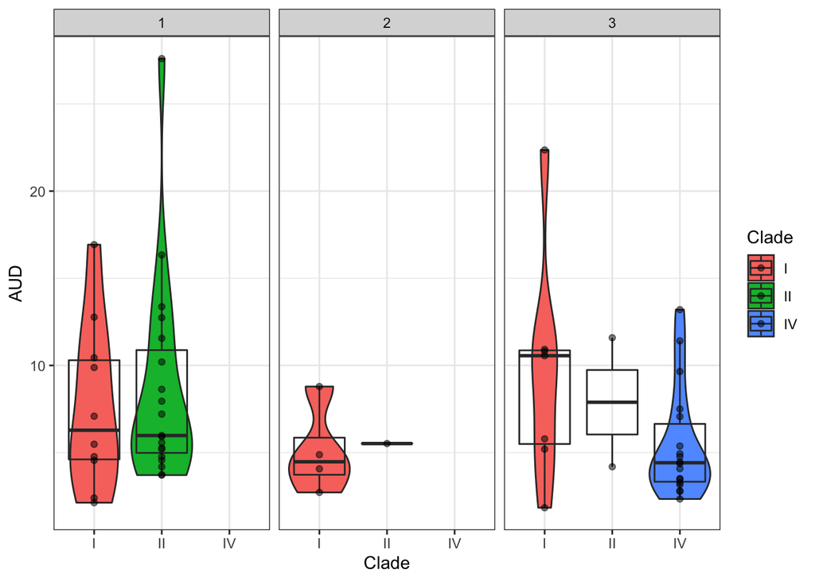

```r
ggplot(myData2) +
  aes(x = Clade, y = AUD, fill = Clade) +
  geom_violin() +
  geom_boxplot(alpha = 0) +
  geom_point(alpha = 0.5) +
  facet_grid(~ Diet)
```

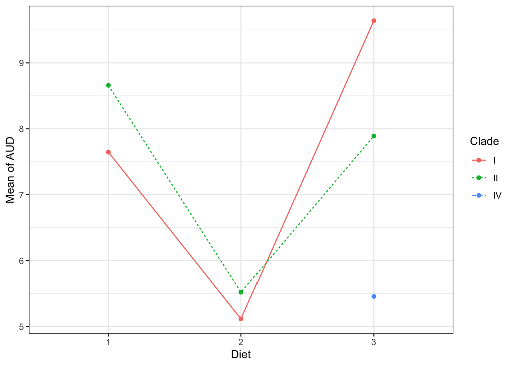

```r
myData2 %>%
  group_by(Diet, Clade) %>%
  summarise(`Mean of AUD` = mean(AUD)) %>%
  ggplot() +
  aes(x = Diet, y = `Mean of AUD`, color = Clade) +
  geom_line(aes(group = Clade, linetype = Clade)) +
  geom_point()
```

## Analyse de la variance à deux facteur

### Modèle

On cherche à modéliser le volume de la partie auditive en fonction de l’évolution et du régime aliementaire. On ne peut pas estimer les interactions entre ces variables car le dispositif est incomplet. Le modèle mathématique associé est donc

$$Y_{i,j,k} = \mu + \alpha_i + \beta_j + E_{i,j,k}$$
où

- $Y_{i,k}$ est le volume de la partie auditive du $k^{\text{ème}}$ individu du $i^{\text{ème}}$ clade et de la $j^{\text{ème}}$ diète,
- $\mu$ est l’effet moyen,
- $\alpha_{i}$ est l’effet spécifique du clade $i$,
- $\beta{j}$ est l’effet spécifique de la diète $j$,
- $\left\{E_{i,j,k}\right\} \overset{iid}{\sim} \mathcal{N}\left(0, \sigma^2\right)$,
- $1 \leq i \leq I = 3$,
- $1 \leq j \leq J = 3$,
- $1 \leq k \leq n_{i,j}$,
- $n_{1,1} = 10$, $n_{1,2} = 4$, $n_{1,3} = 7$, $n_{2,1} = 19$, $n_{2,2} = 1$, $n_{2,3} = 2$, $n_{3,1} = n_{3,2} = 0$, $n_{3,3} = 18$.

```r
anova2 <- lm(AUD ~ Clade + Diet, data = myData2)
```

### Tests

```r
summary(anova2)
```

```
##
## Call:
## lm(formula = AUD ~ Clade + Diet, data = myData2)
##
## Residuals:
##    Min     1Q Median     3Q    Max
## -7.305 -3.116 -1.031  1.883 19.126
##
## Coefficients:
##             Estimate Std. Error t value Pr(>|t|)
## (Intercept)   7.9971     1.3900   5.753 3.82e-07 ***
## CladeII       0.4766     1.6198   0.294   0.7697
## CladeIV      -3.6897     2.0061  -1.839   0.0712 .
## Diet2        -2.8964     2.4543  -1.180   0.2429
## Diet3         1.1481     1.9734   0.582   0.5630
## ---
## Signif. codes:  0 '***' 0.001 '**' 0.01 '*' 0.05 '.' 0.1 ' ' 1
##
## Residual standard error: 4.834 on 56 degrees of freedom
## Multiple R-squared:  0.1022, Adjusted R-squared:  0.03811
## F-statistic: 1.594 on 4 and 56 DF,  p-value: 0.1885
```

La p-valeur associée au modèle est $p =$ 0.1885 donc il n’est pas significatif. On regarde tout de même l’influence des différentes variables qui ne sont pas significatives non plus, sans surprise.

```r
anova(anova2)
```

```
## Analysis of Variance Table
##
## Response: AUD
##           Df  Sum Sq Mean Sq F value Pr(>F)
## Clade      2   95.84  47.922  2.0506 0.1382
## Diet       2   53.19  26.597  1.1381 0.3277
## Residuals 56 1308.72  23.370
```

```r
Anova(anova2)
```

```
## Anova Table (Type II tests)
##
## Response: AUD
##            Sum Sq Df F value Pr(>F)
## Clade       88.46  2  1.8926 0.1602
## Diet        53.19  2  1.1381 0.3277
## Residuals 1308.72 56
```

# Volume de la partie auditive, régime alimentaire et taille du cerveau

## Analyse descriptive

```r
by(myData2$BRW, myData2$Diet, mean)
```

```
## myData2$Diet: 1
## [1] 1410.207
## --------------------------------------------------------
## myData2$Diet: 2
## [1] 384.4
## --------------------------------------------------------
## myData2$Diet: 3
## [1] 432.1915
```

```r
by(myData2$AUD, myData2$Diet, mean)
```

```
## myData2$Diet: 1
## [1] 8.30931
## --------------------------------------------------------
## myData2$Diet: 2
## [1] 5.196
## --------------------------------------------------------
## myData2$Diet: 3
## [1] 6.720741
```

```r
# ou de manière semblable (et même mieux)
myData2 %>%
  group_by(Diet) %>%
  summarise(Effectif = n(),
            `Mean of AUD` = mean(AUD),
            `Mean of BRW` = mean(BRW))
```

```
## # A tibble: 3 x 4
##   Diet  Effectif `Mean of AUD` `Mean of BRW`
##   <fct>    <int>         <dbl>         <dbl>
## 1 1           29          8.31         1410.
## 2 2            5          5.20          384.
## 3 3           27          6.72          432.
```

## Analyse graphique

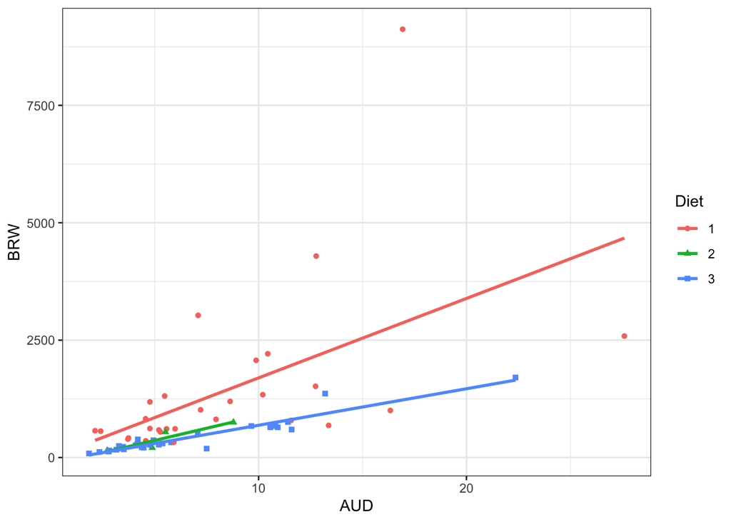

```r
ggplot(myData2) +
  aes(x = AUD, y = BRW, color = Diet, shape = Diet) +
  geom_point() +
  geom_smooth(method = "lm", se = FALSE)
```

## Analyse de la covariance

### Modèle

On cherche à modéliser le volume de la partie auditive en fonction du régime aliementaire et du poids du cerveau total. Le modèle mathématique associé est donc

$$Y_{i,k} = \mu + \alpha_i + (\beta + \gamma_i) \times x_{i,k} + E_{i,k}$$

où

- $Y_{i,k}$ est le volume de la partie auditive du $k^{\text{ème}}$ individu de la $i^{\text{ème}}$ diète,
- $\mu$ est l’effet moyen,
- $\alpha_{i}$ est l’effet spécifique de la diète $i$,
- $\beta$ est la pente commune,
- $\gamma_{i}$ est la pente spécifique de la diète $i$,
- $x_{i,k}$ est le poids du cerveau total du $k^{\text{ème}}$ individu de la $i^{\text{ème}}$ diète,
- $\left\{E_{i,k}\right\} \overset{iid}{\sim} \mathcal{N}\left(0, \sigma^2\right)$,
- $1 \leq i \leq I = 3$,
- $1 \leq k \leq n_{i}$,
- $n_{1} = 29$, $n_{2} = 5$, $n_{3} = 27$.

```r
ancova <- lm(AUD ~ Diet * BRW, data = myData2)
```

### Graphes de diagnostic

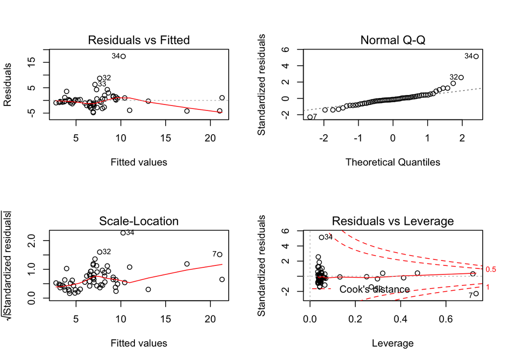

```r
par(mfrow = c(2, 2))
plot(ancova)
```

Le point 7 est atypique. Dans le cadre formel de ce TP, on continue l’analyse sans le retirer en validant les hypothèses de ce modèle.

### Test du modèle

```r
reg0 <- lm(AUD ~ 1, data = myData2)
anova(reg0, ancova)
```

```
## Analysis of Variance Table
##
## Model 1: AUD ~ 1
## Model 2: AUD ~ Diet * BRW
##   Res.Df     RSS Df Sum of Sq      F    Pr(>F)
## 1     60 1457.76
## 2     55  661.21  5    796.55 13.252 1.767e-08 ***
## ---
## Signif. codes:  0 '***' 0.001 '**' 0.01 '*' 0.05 '.' 0.1 ' ' 1
```

Avec $p=0$, le modèle est significatif.

On note par ailleurs que

- la somme des carrés totale vaut 1457.76 sur 60 degrés de liberté,
- la somme des carrés résiduelle vaut 661.21 sur 55 degrés de liberté,
- la somme des carrés due au modèle vaut 796.55 sur 5 degrés de liberté.

### Test des variables

```r
anova(ancova)
```

```
## Analysis of Variance Table
##
## Response: AUD
##           Df Sum Sq Mean Sq F value    Pr(>F)
## Diet       2  60.58   30.29  2.5195   0.08976 .
## BRW        1 384.52  384.52 31.9844 5.756e-07 ***
## Diet:BRW   2 351.46  175.73 14.6173 8.109e-06 ***
## Residuals 55 661.21   12.02
## ---
## Signif. codes:  0 '***' 0.001 '**' 0.01 '*' 0.05 '.' 0.1 ' ' 1
```

```r
Anova(ancova)
```

```
## Anova Table (Type II tests)
##
## Response: AUD
##           Sum Sq Df F value    Pr(>F)
## Diet        9.22  2  0.3836    0.6832
## BRW       384.52  1 31.9844 5.756e-07 ***
## Diet:BRW  351.46  2 14.6173 8.109e-06 ***
## Residuals 661.21 55
## ---
## Signif. codes:  0 '***' 0.001 '**' 0.01 '*' 0.05 '.' 0.1 ' ' 1
```

L’intercation est significative dans le cadre des tests de type I et de type II (on a $p=8.1093458\times 10^{-6} < 0.05 = \alpha$). On conserve donc toutes les varaibles.

### Test des paramètres

```r
summary(ancova)
```

```
##
## Call:
## lm(formula = AUD ~ Diet * BRW, data = myData2)
##
## Residuals:
##     Min      1Q  Median      3Q     Max
## -4.7924 -1.6128 -0.4486  0.6743 17.3482
##
## Coefficients:
##               Estimate Std. Error t value Pr(>|t|)
## (Intercept)  5.9815910  0.8338761   7.173 1.96e-09 ***
## Diet2       -3.9611060  3.1610203  -1.253  0.21547
## Diet3       -4.2154266  1.3218640  -3.189  0.00236 **
## BRW          0.0016506  0.0003758   4.393 5.15e-05 ***
## Diet2:BRW    0.0066103  0.0068400   0.966  0.33806
## Diet3:BRW    0.0098132  0.0018410   5.330 1.89e-06 ***
## ---
## Signif. codes:  0 '***' 0.001 '**' 0.01 '*' 0.05 '.' 0.1 ' ' 1
##
## Residual standard error: 3.467 on 55 degrees of freedom
## Multiple R-squared:  0.5464, Adjusted R-squared:  0.5052
## F-statistic: 13.25 on 5 and 55 DF,  p-value: 1.767e-08
```

### Comparaison des modalités

```r
lsmeans(ancova, pairwise ~ Diet, adjust = "none")
```

```
## $lsmeans
##  Diet lsmean    SE df lower.CL upper.CL
##  1      7.46 0.673 55     6.11      8.8
##  2      9.40 3.805 55     1.77     17.0
##  3     12.01 1.066 55     9.87     14.1
##
## Confidence level used: 0.95
##
## $contrasts
##  contrast estimate   SE df t.ratio p.value
##  1 - 2       -1.94 3.86 55 -0.503  0.6170
##  1 - 3       -4.55 1.26 55 -3.611  0.0007
##  2 - 3       -2.61 3.95 55 -0.660  0.5123
```

```r
lsmeans(ancova, pairwise ~ Diet, adjust = "bonferroni")
```

```
## $lsmeans
##  Diet lsmean    SE df lower.CL upper.CL
##  1      7.46 0.673 55     6.11      8.8
##  2      9.40 3.805 55     1.77     17.0
##  3     12.01 1.066 55     9.87     14.1
##
## Confidence level used: 0.95
##
## $contrasts
##  contrast estimate   SE df t.ratio p.value
##  1 - 2       -1.94 3.86 55 -0.503  1.0000
##  1 - 3       -4.55 1.26 55 -3.611  0.0020
##  2 - 3       -2.61 3.95 55 -0.660  1.0000
##
## P value adjustment: bonferroni method for 3 tests
```

La diète 3 a une influence significativement différente de la diète 1, après correction pour la multiplicité par la méthode de Bonferroni. En revanche, ce n’est pas le cas pour la comparaison entre les diètes 1 et 2, et 2 et 3.